[output not shown]

# Simulations with *slendr*

# Why use simulations?

> Many problems in population genetics cannot be solved by a mathematician, no matter how gifted. [It] is already clear that computer methods are very powerful. This is good. It […] permits people with limited mathematical knowledge to work on important problems […].

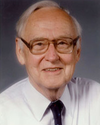

[James F. Crow](https://en.wikipedia.org/wiki/James_F._Crow) – [interview](http://www.gnxp.com/blog/2006/06/10-questions-for-jim-crow.php)

# Why use simulations?

1. Developing intuition into statistics
2. Estimating model parameters
3. Ground truth for method development

## Developing intuition into statistics

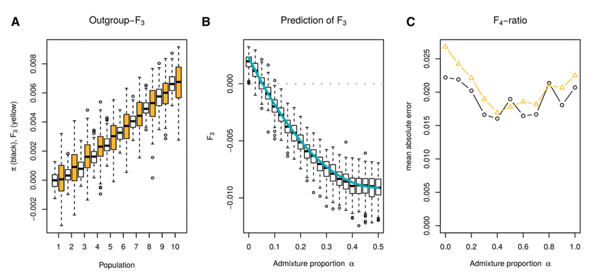

Image from [Peter (2016)](https://academic.oup.com/genetics/article/202/4/1485/5930214)

## Developing intuition into statistics

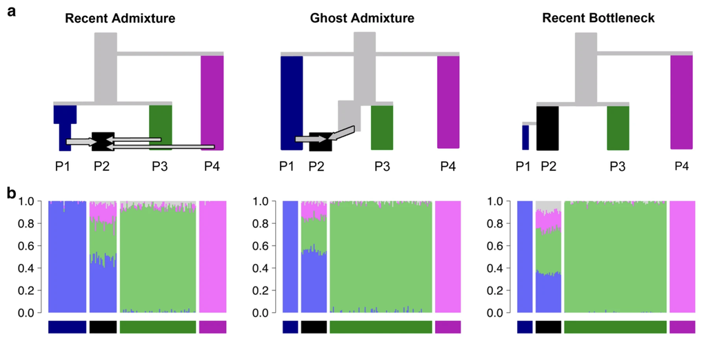

Image from [Lawson *et al.* (2018)](https://www.nature.com/articles/s41467-018-05257-7)

## Estimating model parameters (i.e. [ABC](https://en.wikipedia.org/wiki/Approximate_Bayesian_computation))

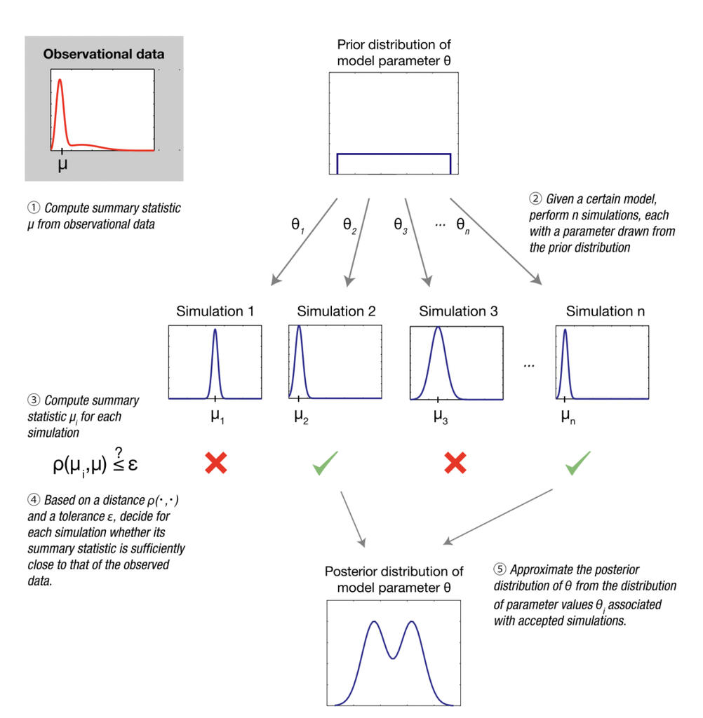

Image from [Wikipedia on ABC](https://en.wikipedia.org/wiki/Approximate_Bayesian_computation)

## Ground truth for method development

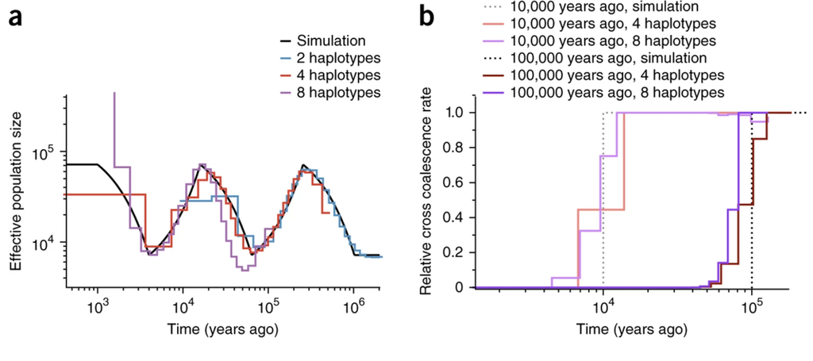

Image from [Schiffels and Durbin (2014)](https://www.nature.com/articles/ng.3015)

## Simulation software

The most famous and widely used are [SLiM](https://messerlab.org/slim/) and [*msprime*](https://tskit.dev/msprime/docs/stable/intro.html).

They are very powerful and (nearly) infinitely flexible.

However, they both require:

- quite a bit of code for complex simulations (“complex” is relative, of course)
- relatively high confidence in programming

#### Our exercises will focus on the [*slendr*](http://www.slendr.net) simulation toolkit for population genetics in R.

But, as a recap, let’s look at *msprime* and SLiM a little bit…

## What is *msprime*?

- A Python module for writing **coalescent simulations**
- Extremely fast (genome-scale, population-scale data!)
- You should know Python fairly well to build complex models

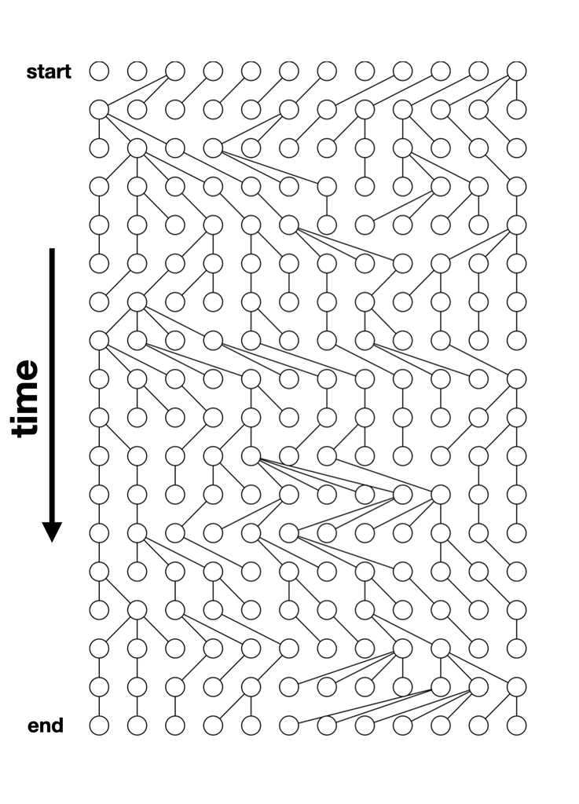

Image modified from [Alexei Drummond](http://alexeidrummond.org/bayesian_phylo_lectures/lecture10/)

## Simple simulation using *msprime*

```
import msprime

demography = msprime.Demography()
demography.add_population(name="A", initial_size=10_000)
demography.add_population(name="B", initial_size=5_000)
demography.add_population(name="C", initial_size=1_000)
demography.add_population_split(time=1000, derived=["A", "B"], ancestral="C")

ts = msprime.sim_ancestry(
  sequence_length=10e6,
  recombination_rate=1e-8,
  samples={"A": 100, "B": 100},
  demography=demography
)
```

## What is SLiM?

- **A forward-time simulator**
- Has its own programming language
- Massive library of functions for:
  - demographic events
  - various mating systems
  - natural selection
- More than 700 pages long [manual](https://github.com/MesserLab/SLiM/releases/download/v4.3/SLiM_Manual.pdf)!

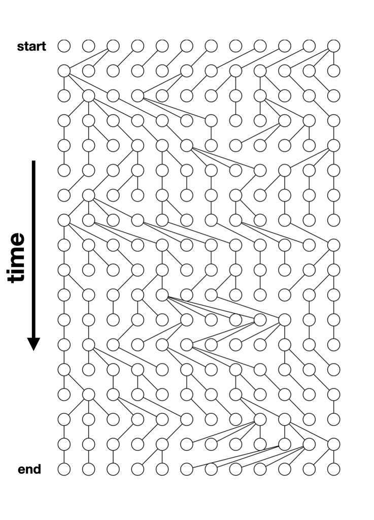

Image modified from [Alexei Drummond](http://alexeidrummond.org/bayesian_phylo_lectures/lecture10/)

## Simple neutral simulation in SLiM

```
initialize() {
    // create a neutral mutation type
    initializeMutationType("m1", 0.5, "f", 0.0);

    // initialize 1Mb segment
    initializeGenomicElementType("g1", m1, 1.0);
    initializeGenomicElement(g1, 0, 999999);

    // set mutation rate and recombination rate of the segment
    initializeMutationRate(1e-8);
    initializeRecombinationRate(1e-8);
}

// create an ancestral population p1 of 10000 diploid individuals
1 early() { sim.addSubpop("p1", 10000); }

// in generation 1000, create two daughter populations p2 and p3
1000 early() {
    sim.addSubpopSplit("p2", 5000, p1);
    sim.addSubpopSplit("p3", 1000, p1);
}

// in generation 10000, stop the simulation and save 100 individuals
// from p2 and p3 to a VCF file
10000 late() {
    p2_subset = sample(p2.individuals, 100);
    p3_subset = sample(p3.individuals, 100);
    c(p2_subset, p3_subset).genomes.outputVCF("/tmp/slim_output.vcf.gz");

    sim.simulationFinished();
}
```

### SLiM and *msprime* are both incredible pieces of software…

## … so why *slendr*?

[figure not shown]

## First motivation: spatial simulations!

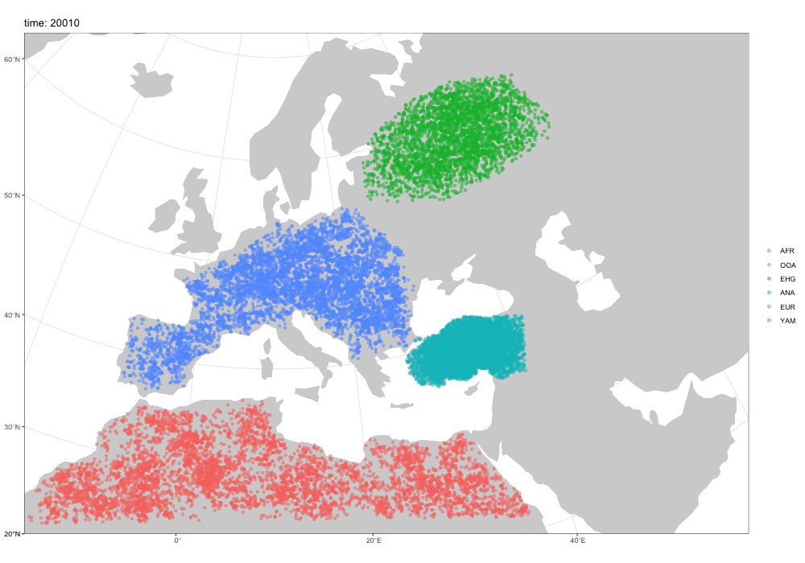

## A broader motivation for *slendr*

- Most researchers are not expert programmers
- All but the most trivial simulations require lots of code
- Yet, 90% <sup>[citation needed]</sup> of simulations are basically the same!
  - create populations (splits and $N_e$ changes)
  - specify admixture rates and admixture times
- … all this means duplication of code across many projects
- Computing statistics presents even more hurdles

#### *slendr* makes this very easy, even for “complex models”

# *slendr* crash course

You can use this document as a cheat sheet as you work on the exercises. It contains everything you need to know about *slendr*, in a compressed form.

## Typical *slendr* workflow

We will always start our R scripts with this:

```r
library(slendr)     # You can safely ignore any potential warnings!
init_env(uv = TRUE) # This activates the internal Python environmet
```

Followed by some combination of the following:

1. creating populations
2. programming $N_e$ size changes
3. encoding gene-flow events
4. simulating genomic data
5. computing popgen statistics

## Creating populations

At minimum, we need its name, size and “time of appearance”:

```r
pop1 <- population("pop1", N = 1000, time = 1)
```

This creates a normal R object! Typing it out gives a summary:

```r
pop1
```

```
slendr 'population' object
--------------------------
name: pop1
non-spatial population
stays until the end of the simulation

population history overview:
  - time 1: created as an ancestral population (N = 1000)
```

**Note:** Because *slendr* uses either *msprime* or SLiM internally for simulation of genomic data, all individuals are assumed to be diploid.

## Programming population splits

Splits are defined by providing a `parent = <pop>` argument:

```r
pop2 <- population("pop2", N = 100, time = 50, parent = pop1)
```

**Note:** Here `pop1` is an R object created above, not a string `"pop1"`!

The split is again reported in the “historical summary”:

```r
pop2
```

```
slendr 'population' object
--------------------------
name: pop2
non-spatial population
stays until the end of the simulation

population history overview:
  - time 50: split from pop1 (N = 100)
```

## Scheduling resize events

- Step size decrease:

```r
pop1 <- population("pop1", N = 1000, time = 1)
pop1_step <- resize(pop1, N = 100, time = 500, how = "step")
```

- Exponential increase:

```r
pop2 <- population("pop2", N = 100, time = 50, parent = pop1)
pop2_exp <- resize(pop2, N = 10000, time = 500, end = 2000, how = "exponential")
```

## Tidyverse-style [pipe](https://magrittr.tidyverse.org) `%>%` interface

The following leads to a more concise (and “elegant”) code.

- Step size decrease:

```r
pop1 <-
  population("pop1", N = 1000, time = 1) %>%
  resize(N = 100, time = 500, how = "step")
```

- Exponential increase:

```r
pop2 <-
  population("pop2", N = 1000, time = 1) %>%
  resize(N = 10000, time = 500, end = 2000, how = "exponential")
```

**Note:** You can read (and understand) `a() %>% b() %>% c()` as “take the result of the function `a`, pipe it into function `b`, and then pipe *that* to function `c`”.

## A more complex model

Using just the two functions introduced so far:

```r
pop1 <- population("pop1", N = 1000, time = 1)

pop2 <-
  population("pop2", N = 1000, time = 300, parent = pop1) %>%
  resize(N = 100, how = "step", time = 1000)
pop3 <-
  population("pop3", N = 1000, time = 400, parent = pop2) %>%
  resize(N = 2500, how = "step", time = 800)
pop4 <-
  population("pop4", N = 1500, time = 500, parent = pop3) %>%
  resize(N = 700, how = "exponential", time = 1200, end = 2000)
pop5 <-
  population("pop5", N = 100, time = 600, parent = pop4) %>%
  resize(N = 50, how = "step", time = 900) %>%
  resize(N = 1000, how = "exponential", time = 1600, end = 2200)
```

## Again, each object carries its history!

For instance, this is the summary you will get from the last population from the previous code chunk:

```r
pop5
```

```
slendr 'population' object
--------------------------
name: pop5
non-spatial population
stays until the end of the simulation

population history overview:
  - time 600: split from pop4 (N = 100)
  - time 900: resize from 100 to 50 individuals
  - time 1600-2200: exponential resize from 50 to 1000 individuals
```

**This way, you can build up complex models step by step, checking things as you go by interacting with the R console.**

## Gene flow / admixture

We can schedule gene flow from `pop1` into `pop2` with:

```r
gf <- gene_flow(from = pop1, to = pop2, start = 2000, end = 2200, proportion = 0.13)
```

**Note:** Here `proportion = 0.13` means 13% migrants over the given time window will come from “pop1” into “pop2”.

Multiple gene-flow events can be gathered in a list:

```r
gf <- list(
  gene_flow(from = pop1, to = pop2, start = 500, end = 600, proportion = 0.13),
  gene_flow(from = ..., to = ..., start = ..., end = ..., proportion = ...),
  ...
)
```

## Model compilation

This is the final step before we can simulate data.

```r
model <- compile_model(
  populations = list(pop1, pop2, pop3, pop4, pop5),
  generation_time = 1,       # (converts the all times into generations)
  simulation_length = 3000,  # (number of generations to run the simulation for)
  direction = "forward"      # (not totally necessary but good practice)
)
```

**`compile_model()` takes a list of components, performs some consistency checks, and returns a single R object**

## Model compilation

This is the final step before we can simulate data.

```r
model <- compile_model(
  populations = list(pop1, pop2, pop3, pop4, pop5),
  gene_flow = gf,      # <----- in case our model includes gene flow(s)
  generation_time = 1,
  simulation_length = 3000,
  direction = "forward"
)
```

**Gene flow(s) can be included via the `gene_flow` argument.**

## Model summary

Typing the compiled `model` into R prints a brief summary:

```r
model
```

```
slendr 'model' object
---------------------
populations: pop1, pop2, pop3, pop4, pop5
geneflow events: 1
generation time: 1
time direction: forward
time units: generations
total running length: 3000 time units
model type: non-spatial

configuration files in: /private/var/folders/7f/n68ck8q969z_d628zqqnl4ch0000gn/T/RtmpY2TjYt/file3fbe61ed3074_slendr_model
```

This can be useful as a quick overview of the model we are working with. However, **a better way to check a model is…**

## Model visualization

```r
plot_model(model)
```

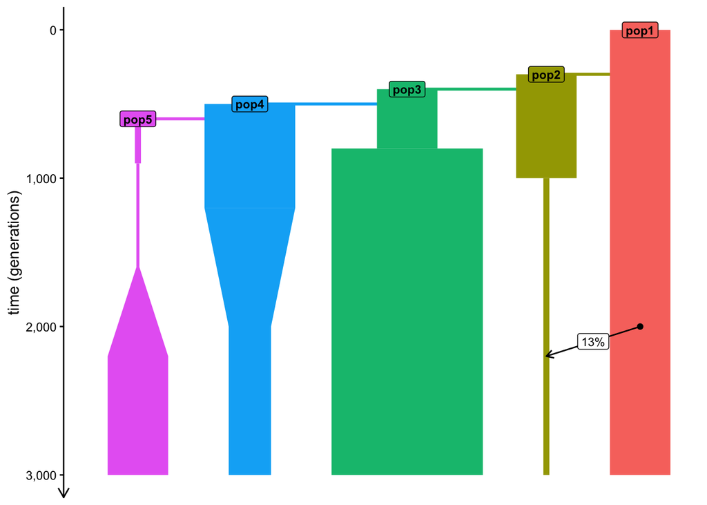

# A note on units of time (and its direction)

Sometimes you want to work with time units such as “years ago” (aDNA radio-carbon dated samples, etc.), but you have to convert those to “generations forward” for some software.

*slendr* helps by making it possible to use whatever time units or time directions are more natural for a particular project.

## “Forward time units”

```r
pop1 <- population("pop1", N = 1000, time = 1)

pop2 <-
  population("pop2", N = 1000, time = 300, parent = pop1) %>%
  resize(N = 100, how = "step", time = 1000)
pop3 <-
  population("pop3", N = 1000, time = 400, parent = pop2) %>%
  resize(N = 2500, how = "step", time = 800)
pop4 <-
  population("pop4", N = 1500, time = 500, parent = pop3) %>%
  resize(N = 700, how = "exponential", time = 1200, end = 2000)
pop5 <-
  population("pop5", N = 100, time = 600, parent = pop4) %>%
  resize(N = 50, how = "step", time = 900) %>%
  resize(N = 1000, how = "exponential", time = 1600, end = 2200)
model <- compile_model(
  populations = list(pop1, pop2, pop3, pop4, pop5),
  generation_time = 1,
  simulation_length = 3000, # forward-time sims need an explicit end
  direction = "forward"
)
```

**We started with `pop1` in generation 1, with later events at an increasing time value.**

## “Forward time units”

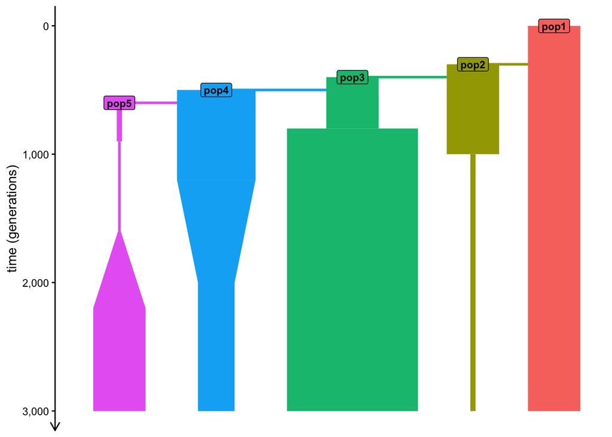

```r
plot_model(model) # see time progressing from generation 1 forwards
```

**We started with `pop1` in generation 1, with later events at an increasing time value.**

## “Backward time units”

```r
pop1 <- population("pop1", N = 1000, time = 30000)

pop2 <-
  population("pop2", N = 1000, time = 27000, parent = pop1) %>%
  resize(N = 100, how = "step", time = 20000)
pop3 <-
  population("pop3", N = 1000, time = 26000, parent = pop2) %>%
  resize(N = 2500, how = "step", time = 22000)
pop4 <-
  population("pop4", N = 1500, time = 25000, parent = pop3) %>%
  resize(N = 700, how = "exponential", time = 18000, end = 10000)
pop5 <-
  population("pop5", N = 100, time = 24000, parent = pop4) %>%
  resize(N = 50, how = "step", time = 21000) %>%
  resize(N = 1000, how = "exponential", time = 14000, end = 8000)
model <- compile_model(
  populations = list(pop1, pop2, pop3, pop4, pop5),
  generation_time = 10 # (10 time units for each generation)
  # (we don't need to provide `simulation_length =` because
  # "backwards" models end at time 0 by default, i.e. "present-day")
)
```

**Same model as before, except now expressed in units of “years before present”.**

## “Backward time units”

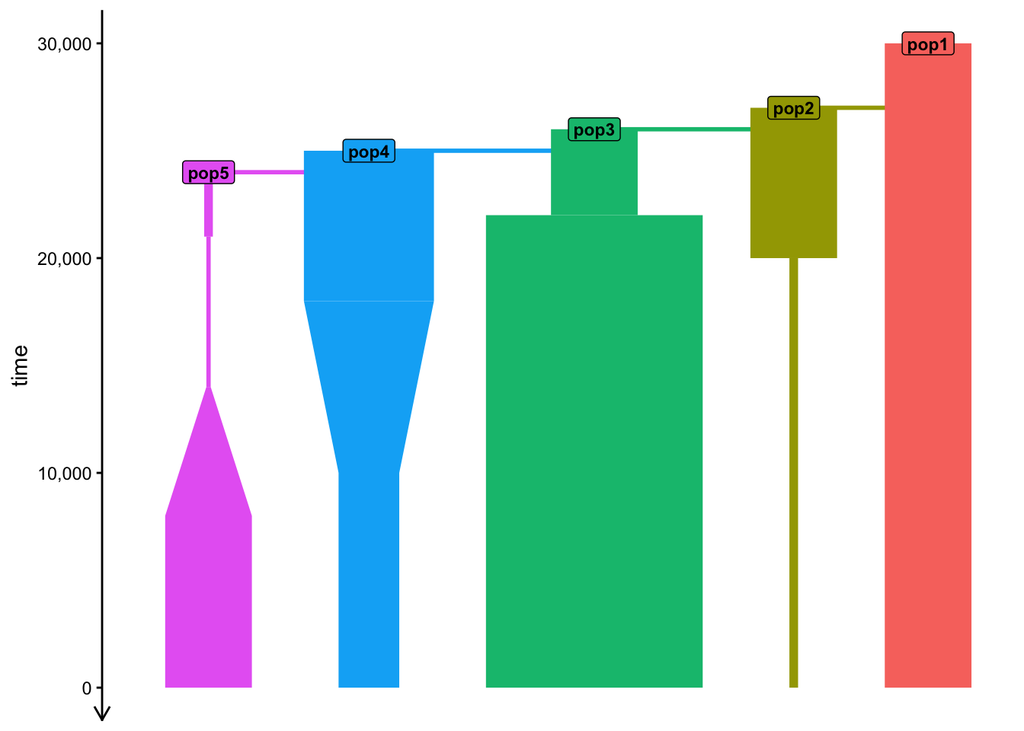

```r
plot_model(model) # see time progressing from "year" 30000 backwards
```

**Same model as before, except now expressed in units of “years before present”.**

# So we built a model…

### … but how do we simulate data from it?

## Built-in simulation “engines”

*slendr* has two simulation “engine scripts” built-in:

- *msprime* engine ([*slendr* source](https://github.com/bodkan/slendr/blob/main/inst/scripts/script.py)) – R function `msprime()`
- SLiM engine ([*slendr* source](https://github.com/bodkan/slendr/blob/main/inst/scripts/script.slim)) – R function `slim()`

They are designed to “understand” *slendr* `model`s, meaning that you can simulate data just with this command:

```r
ts <- msprime(model, sequence_length = 10e6, recombination_rate = 1e-8)
```

### **No need to write any *msprime* or SLiM code!**

# The result of a simulation is a tree sequence (`ts`)

## What is tree sequence?

- a record of full genetic ancestry of a set of samples
- an encoding of DNA sequence carried by those samples
- an efficient analysis framework

# Why tree sequence?

### Why not VCF or a normal genotype table?

## What we usually have

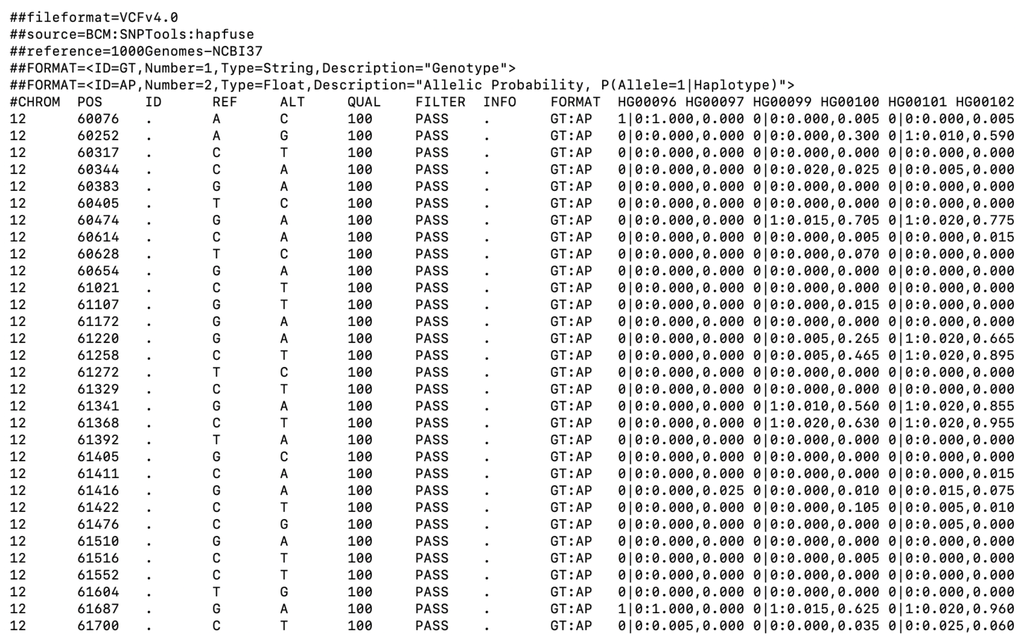

## The magic of tree sequences

They allow us to compute statistics *without genotypes*!

There is a “duality” between mutations and branch lengths.

**Note:** See an amazing paper by [Ralph *et al.* (2020)](https://academic.oup.com/genetics/article/215/3/779/5930459) for more detail.

## What if we need mutations though?

## What if we need mutations though?

Coalescent and mutation processes can be decoupled!

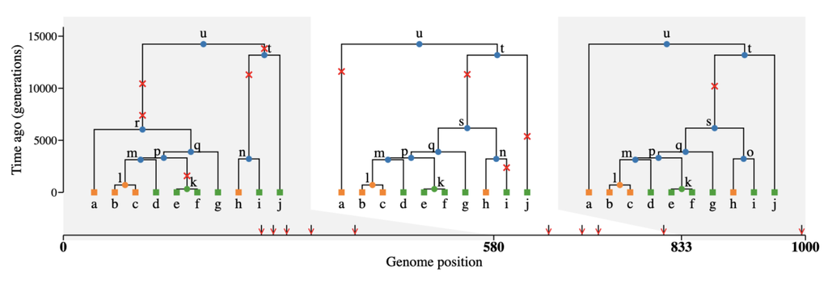

### This means we can add mutations to `ts` *after* the simulation using `ts_mutate()`.

## Let’s go back to our example `model`…

```r
plot_model(model)
```

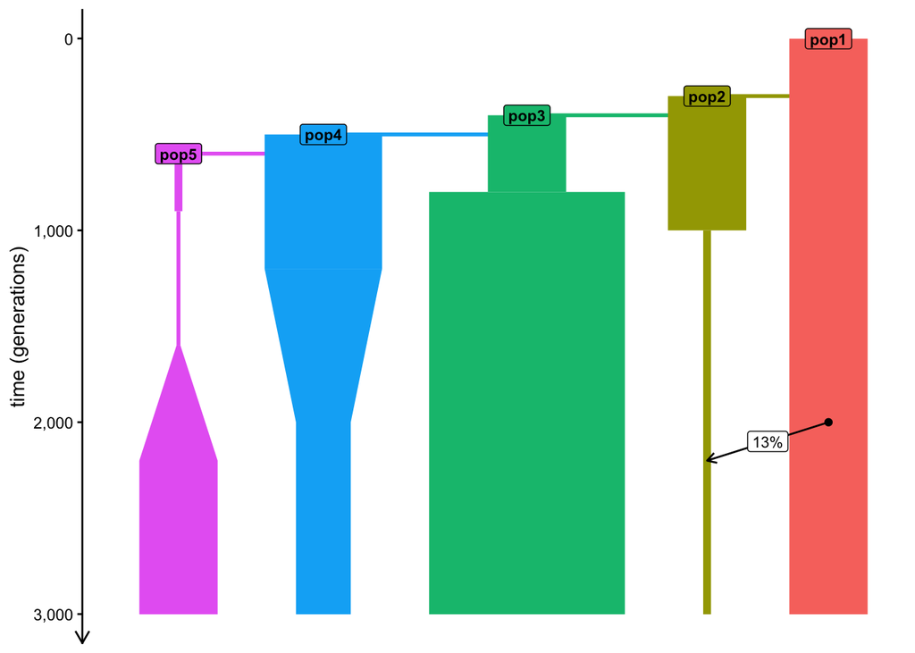

## … simulate a tree sequence…

In our script we’ll have something like this:

```r
library(slendr)
init_env(uv = TRUE)

# <... population() definitions ...>

# <... gene_flow() definition ...>

# <... compile_model(...) ...>

ts <-
  msprime(model, sequence_length = 50e6, recombination_rate = 1e-8)
```

## … and overlay mutations on it

In our script we’ll have something like this:

```r
library(slendr)
init_env(uv = TRUE)

# <... population() definitions ...>

# <... gene_flow() definition ...>

# <... compile_model(...) ...>

ts <-
  msprime(model, sequence_length = 50e6, recombination_rate = 1e-8) %>%
  ts_mutate(mutation_rate = 1e-8)
```

**Note:** In some exercises, mutations won’t be necessary. Where we will need them, you can use `ts_mutate()` using the pattern shown here.

# So we can simulate data

### How do we work with this `ts` thing?

## *slendr*’s R interface to [*tskit*](https://tskit.dev/tskit) statistics

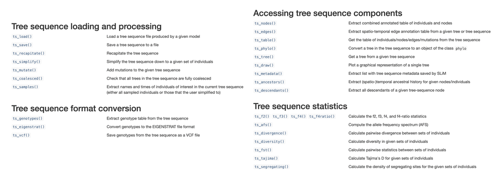

Allele-frequecy spectrum, $\pi$, $f$-statistics, $F_{ST}$, Tajima’s D, etc.

**Find help at slendr.net/reference or in R under `?ts_fst` etc.**

## Extracting names of recorded samples

1. We can get individuals recorded in `ts` with `ts_recorded()`:

```r
ts_recorded(ts) %>% head(1) # returns a data frame (one row here, for brevity)
```

```
    name time  pop
1 pop1_1 3001 pop1
```

2. A shortcut `ts_names()` can also be useful:

```r
ts_names(ts) %>% head(5) # returns a vector of individuals' names
```

```
[1] "pop1_1" "pop1_2" "pop1_3" "pop1_4" "pop1_5"
```

3. We can get a per-population list of individuals like this:

```r
ts_names(ts, split = TRUE) # returns a named list of such vectors
```

```
$pop1
[1] "pop1_765" "pop1_134" "pop1_697" "pop1_191" "pop1_770"
```

## All *slendr* statistics take individuals’ names as their function arguments.

This is modelled after the `sample_sets=` argument of the respective [*tskit* Python methods](https://tskit.dev/tskit/docs/stable/python-api.html#statistics) (except you use names of individuals directly, not tree-sequence node numbers).

Let’s take a look at how it works in general…

## *tskit* computation – option #1

**For a function which operates on one set of individuals**, we can first get a vector of names to compute on like this:

```r
# a random selection of names of three individuals in a tree sequence
samples <- c("popX_1", "popX_2", "popY_42")
```

Then we can calculate the statistic of interest like this:

```r
# this computes nucleotide diversity in our set of individuals
df_result <- ts_diversity(ts, sample_sets = list(samples))
```

**Note:** Wherever you see `list(<vector of names>)`, you can think of it as *“compute a statistic for the entire group of individuals”* (you get a single number). Without the `list()`, it would mean *“compute the statistic for each individual separately”* (and get a value for each of them individually).

## *tskit* computation – option #2

For a function operating on multiple sets of individuals, we want a list of vectors of names (one such vector per group):

```r
# when we compute on multiple groups, it's a good idea to name them
samples <- list(
  popX = c("popX_1", "popX_2", "popX_3"),
  popY = c("popY_1", "popY_2", "popY_3"),
  popZ = c("popZ_1", "popZ_2")
)
```

Then we use this list of vectors in the same way as before:

```r
# this computes a pairwise divergence between all three groups
df_result <- ts_divergence(ts, sample_sets = samples)
```

## *tskit* computation – option #3

For something like $f$ statistics, the function arguments must be more precisely specified (here `A`, `B`, `C`, not `sample_sets`):

```r
df_result <- ts_f3(
  ts,
  A = c("popX_1", "popX_2", "popX_3"),
  B = c("popY_1", "popY_2", "popY_3"),
  C = c("popZ_1", "popZ_2")
)
```

Doing this manually can be annoying — `ts_names()` helps by preparing the list of names in the correct format:

```r
# get names of individuals in each population as a named list of vectors
samples <- ts_names(ts, split = TRUE)

# use this list directly by specifying which vectors to take out
ts_f3(ts, A = samples$popX, B = samples$popY, C = samples$popZ)
```

# Some examples on simulated data

## Example: [nucleotide diversity](https://en.wikipedia.org/wiki/Nucleotide_diversity)

Get a list of individuals in each population:

```r
samples <- ts_names(ts, split = TRUE)

names(samples)
```

```
[1] "pop1" "pop2"
```

We can index into the list via population name:

```r
samples$pop1
```

```
[1] "pop1_1" "pop1_2" "pop1_3"
```

```r
samples$pop2
```

```
[1] "pop2_1" "pop2_2" "pop2_3"
```

Compute nucleotide diversity (note the list `samples`):

```r
ts_diversity(ts, sample_sets = samples)
```

```
# A tibble: 2 × 2
  set   diversity
  <chr>     <dbl>
1 pop1  0.000399
2 pop2  0.0000594
```

Our tree sequence had two populations, `pop1` and `pop2`, which is why we get a data frame with diversity in each of them.

## Example: [allele frequency spectrum](https://en.wikipedia.org/wiki/Allele_frequency_spectrum)

Get names of individuals:

```r
samples <- ts_names(ts)[1:5]
samples
```

```
[1] "pop_1" "pop_2" "pop_3" "pop_4" "pop_5"
```

Compute the AFS:

```r
afs <- ts_afs(ts, sample_sets = list(samples))

# we skip the 1st item because it has a special meaning in tskit
afs[-1]
```

```
 [1] 3917 2151 1432  941  740  624  607  587  416  385
```

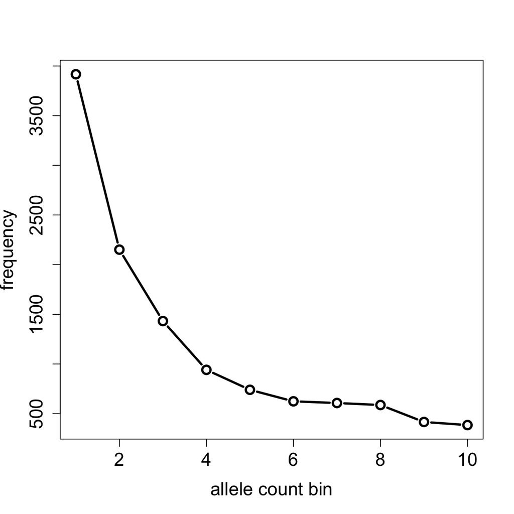

```r
plot(afs[-1], type = "b",
     xlab = "allele count bin",
     ylab = "frequency")
```

**Note:** One of the rare examples when a *slendr* / *tskit* statistical function does not return a data frame (`ts_afs()` returns a numerical vector, not a data frame).

## More details on tree-sequences

## Tree sequence tables

```r
library(slendr)
init_env(uv = TRUE)

pop <- population("pop", time = 100e6, N = 10000)
model <- compile_model(pop, generation_time = 30, direction = "backward")
ts <- msprime(model, sequence_length = 1e6, recombination_rate = 1e-8)
```

**Runs in less than 30 seconds on my laptop!**

**Takes only about 66 Mb of memory!**

## How is this even possible?!

[figure not shown]

## Tree-sequence tables

A tree can be represented by

- a table of nodes,
- a table of edges between nodes,
- a table of mutations on edges

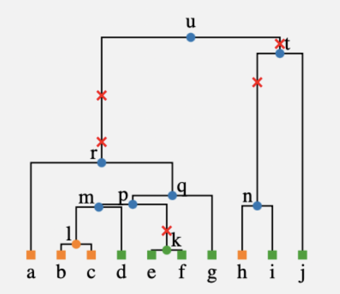

### **A collection of such tables is a tree sequence.**

**Note:** This is a huge oversimplification. Find more information in [tskit docs](https://tskit.dev/tutorials/tables_and_editing.html).

## Tree-sequence tables in practice

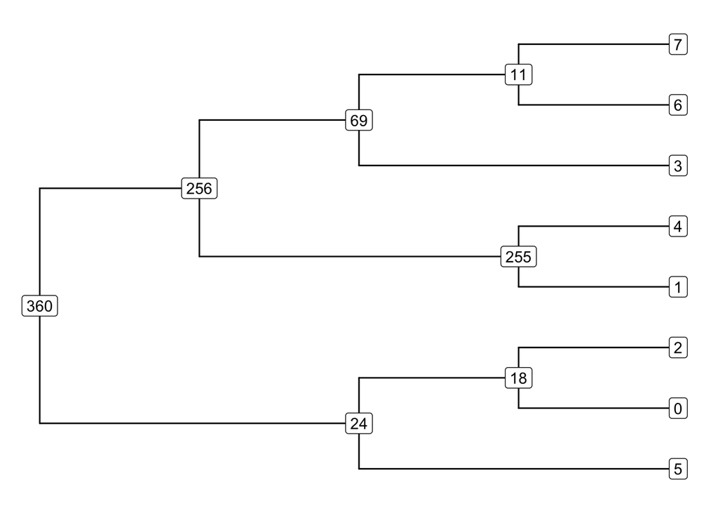

**Nodes:**

```
  node     time
1  360 871895.1
2  256 475982.3
3  255 471179.5
```

**Edges:**

```
  child parent
1   256    360
2   255    256
3    69    256
```

**Mutations:**

```
   id node     time
1  69   74 125539.4
2 272   22 242337.9
3 277   22 129474.1
```

# Other data formats

Tree sequence is a useful, cutting-edge data structure, but there are many well-established bioinformatics tools out there.

*tskit* and *slendr* offer a couple of functions to help integrate their simulation results into third-party software.

[output not shown]

## Standard genotype formats

If a tree sequence doesn’t cut it, you can always…

- export genotypes to a VCF file:

```r
ts_vcf(ts, path = "path/to/a/file.vcf.gz")
```

- export genotypes in the EIGENSTRAT format:

```r
ts_eigenstrat(ts, prefix = "path/to/eigenstrat/prefix")
```

- access genotypes as a data frame:

```r
ts_genotypes(ts)
```

```
    pos pop_1_chr1 pop_1_chr2 pop_2_chr1 pop_2_chr2 pop_3_chr1 pop_3_chr2
1 12977          0          1          0          0          0          0
2 15467          1          0          1          1          1          1
```

# Exercises!

## Plan for the rest of this session

1. Go to bodkan.net/simgen
2. Start with the section on *“Demographic models”*
3. Then, continue with the section on *“Tree-sequence statistics”*

For convenience, you can refer to information from these slides using their single-page version under the *“Resources”* section.

. . .

### Don’t rush and don’t panic!

The exercises are designed so that you all take home information useful for your current skills and knowledge.